# Initial EDA Basic Outline

Guilherme Lima

## Research Question

In F1, drivers may complete circuits many times, but due to many conditions (such as weather, constructor, hazard), these drivers may get different results in these circuits across many seasons. This research question is aimed at addressing who is the most consistent driver for each circuit.

RQ: After the points system change in 2010, what is the average points value for drivers on each circuit? In addition, what is the highest average points value for each circuit, and which driver is it attributed to?

Conditions:

1. The data must only use the new points system values, starting with the 2010 season.
2. The data will not include the 2023 season since it has not been completed.
3. The analysis will only include drivers who have raced on a particular circuit more than 10 times, in order to have a larger sample size; allowing for a more accurate representation of the sample average. In addition, this threshold is also to limit the size of the final output to reasonably fit on a graph.

## Data Processing

#### Data Intake

The data is collected from an F1 dataset on Kaggle. It contains various datasets detailing races, results, drivers, constructors, qualifying results, and many more from the years 1950-2023.

https://www.kaggle.com/datasets/rohanrao/formula-1-world-championship-1950-2020

```r
library(tidyverse)
results <- read.csv("results.csv")
```

[output not shown]

```r
drivers <- read.csv("drivers.csv")
races <- read.csv("races.csv")
circuits <- read.csv("circuits.csv")
#load in all datasets and required packages
```

#### Data Wrangling

```r
currentRaces <- races %>% filter(year >= 2010 & year <= 2022)
#filter races dataset to only include races from 2010-2022

races <- currentRaces %>% select(raceId, circuitId, year)
circuits <- circuits %>% select(circuitId, name)
drivers <- drivers %>% select(driverId, driverRef)
results <- results %>% select(raceId,driverId, points)
```

[output not shown]

```r
#select necessary columns for future table joins
```

```r
racesWithCircuits <- right_join(races, circuits, by = "circuitId")
racesWithCircuits <- drop_na(racesWithCircuits)
#join the races and circuits dataframes by circuitId , and keep all columns in circuits dataframe

resultsWithDrivers <- right_join(results, drivers, by = "driverId")
resultsWithDrivers <- drop_na(resultsWithDrivers)
#join the results and drivers dataframes by driverId, and keep all colummns in drivers dataframe

racesResults <- full_join(racesWithCircuits, resultsWithDrivers, by = "raceId")
racesResults <- drop_na(racesResults)
#join the racesWithCircuits and resultsWithDrivers dataframes by raceId, and keep all columns in both dataframes
```

```r
str(racesResults)
```

```
'data.frame':   5517 obs. of  7 variables:
 $ raceId   : int  337 337 337 337 337 337 337 337 337 337 ...
 $ circuitId: int  3 3 3 3 3 3 3 3 3 3 ...
 $ year     : int  2010 2010 2010 2010 2010 2010 2010 2010 2010 2010 ...
 $ name     : chr  "Bahrain International Circuit" "Bahrain International Circuit" "Bahrain International Circuit" "Bahrain International Circuit" ...
 $ driverId : int  4 13 1 20 3 30 18 17 24 22 ...
 $ points   : num  25 18 15 12 10 8 6 4 2 1 ...
 $ driverRef: chr  "alonso" "massa" "hamilton" "vettel" ...
```

We see here that the columns are as follows:

raceId: a unique identifier for a race in a season

circuitId: a unique identifier for a circuit

year: season of the race

name: name of the circuit

driverId: a unique identifier for a driver

points: a numeric value between 0 and 26 for the points a driver has eared in a race

driverRef: a string for a driver’s reference name, this is used because sometimes drivers have the same last name

```r
test <- racesResults %>% group_by(name, driverId, year) %>% arrange(driverId, circuitId)
```

```r
averageCircuitPoints <- racesResults %>% group_by(driverRef, name) %>% summarise(totalPoints = sum(points), numRaces = n()) %>%
mutate(averagePoints = totalPoints/ numRaces) %>%
  arrange(desc(averagePoints))
#find the average circuit points for each driver by getting the total points they have gained for a circuit, and dividing it by the number of times they have completed that circuit

filteredAverageCircuitPoints <- averageCircuitPoints %>% filter(numRaces > 10 ) %>% group_by(driverRef) %>% arrange(driverRef, desc(averagePoints))
head(filteredAverageCircuitPoints)
```

| driverRef | name | totalPoints | numRaces | averagePoints |
| --- | --- | --- | --- | --- |
| alonso | Hungaroring | 115 | 11 | 10.454545 |
| alonso | Silverstone Circuit | 87 | 11 | 7.909091 |
| alonso | Autódromo José Carlos Pace | 85 | 11 | 7.727273 |
| alonso | Circuit de Barcelona-Catalunya | 85 | 11 | 7.727273 |
| alonso | Autodromo Nazionale di Monza | 77 | 11 | 7.000000 |
| alonso | Yas Marina Circuit | 63 | 11 | 5.727273 |

```r
#filter the average circuit points for drivers who have completed the circuit more than 10 times



maxAveragePoints <- filteredAverageCircuitPoints %>%
  group_by(name) %>%
  filter(averagePoints == max(averagePoints)) %>%
  ungroup() %>%
  select(name, driverRef, averagePoints)
head(maxAveragePoints)
```

| name | driverRef | averagePoints |
| --- | --- | --- |
| Silverstone Circuit | hamilton | 19.64286 |
| Yas Marina Circuit | hamilton | 18.76923 |
| Bahrain International Circuit | hamilton | 18.08333 |
| Hungaroring | hamilton | 18.07692 |
| Circuit Gilles Villeneuve | hamilton | 17.27273 |
| Suzuka Circuit | hamilton | 15.54545 |

```r
#find the maximum "average points" for each circuit, and include the driver reference name
```

## Data Visualization

#### Plot 1

We observe that the outliers in this graph are Raikkonen and Hulkenberg, both of whom only have over 10 races in 3 or less circuits of the ones in the table.

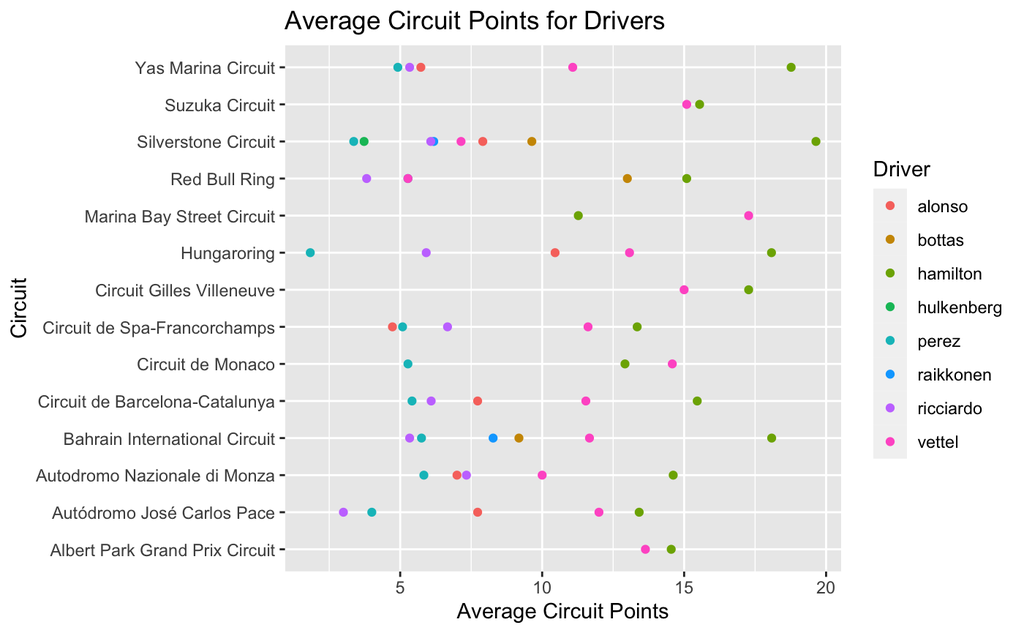

```r
filteredAverageCircuitPoints %>%
  ggplot(aes(x=averagePoints, y=name)) + geom_point(aes(color=driverRef)) + labs(x= "Average Circuit Points", y= "Circuit", color = "Driver", title = "Average Circuit Points for Drivers")
```

#### Plot 2

The graph below depicts the relationship between the highest average points for a circuit, by the circuit name. This graph is colored by the driver name for ease of identification. We observe that Hamilton has the highest average points on F1 circuits for most circuits.

Vettel has the highest average points for only two circuits, Marina Bay Street Circuit, and Circuit de Monaco, indicating an overall more consistent performance in those circuits compared to other drivers.

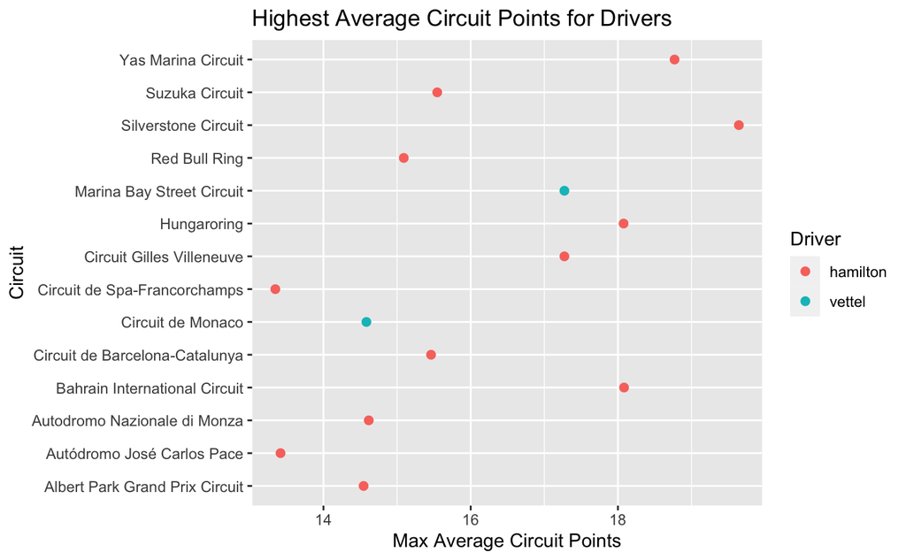

```r
maxAveragePoints %>%
  ggplot(aes(x = averagePoints, y = name, color = driverRef)) +
  geom_point(shape = "circle", size = 2.0) + labs(x= "Max Average Circuit Points", y= "Circuit", color = "Driver", title = "Highest Average Circuit Points for Drivers")
```

## Conclusion

Also, we further refined our criteria to see that Vettel is the more consistent driver for the Maina Bay Street Circuit and Circuit de Monaco.

##Future Questions To Address

For Hamilton and Vettel, what is the average starting position when included in this dataset? It would be interesting to observe if these drivers started from an advantageous starting position due to qualifying results or if they had to overtake during the race.